# Reusable elements

## Typst functions

In Typst, `#let` is your primary building block for reusable formatting and construction. Use it to avoid repeating the same patterns.

```
#let banner(message, note) = [
  #strong(message)
  #v(0.3em)
  #quote(note)
]

#banner("Reusable functions", "Define UI once and reuse it for many places.")
```

The `calepin` namespace also includes a compact set of reusable elements for cards, galleries, columns, tabs, and lightbox media. They are designed to demonstrate output-aware patterning in practical notebook websites.

## Output-aware formatting

Calepin exposes `#calepin.elements.target()` to pick content for HTML, static outputs, or a fallback. This example uses colors to make output differences explicit. In Typst `0.15`, HTML color output was not fully supported, so HTML branches use explicit CSS via `html.elem()`.

```
#let html-color-label(body, color) = html.elem("span", attrs: (style: "color: " + color + ";"))[
  #body
]

#calepin.elements.target(
  html: () => [#html-color-label([#strong("HTML")], "blue") output branch],
  paged: () => [#text(fill: green)[#strong("PDF/SVG")] output branch],
  fallback: () => [#text(fill: gray)[#strong("Fallback")] output branch],
)
```

The rendered result:

**HTML** output branch

## Card

`calepin.elements.card` keeps one piece of content boxed consistently across formats.

```
#let callout = calepin.elements.card[
  #heading(level: 3)[Reusable card]
  A card wraps content with matching style in HTML and paged output.
]
#callout
```

#### Reusable card

A card wraps content with matching style in HTML and paged output.

## Callouts

`calepin.elements.callout` renders AsciiDoc-style admonitions in HTML and paged output. Use `kind:` with `note`, `tip`, `important`, `caution`, or `warning`. The title defaults to the capitalized kind label; pass `title: [...]` to override it, or `title: none` to hide the title row.

```
#calepin.elements.callout(kind: "note")[
  Notes highlight neutral supporting information.
]
```

Note

Notes highlight neutral supporting information.

```
#calepin.elements.callout(kind: "warning", title: [Heads up])[
  Warnings flag potential problems before they happen.
]
```

Heads up

Warnings flag potential problems before they happen.

You can also define a project-specific helper with Typst’s `.with()` method:

```
#let callout-custom = calepin.elements.callout.with(
  kind: "important",
  title: [Project note],
)

#callout-custom[
  Use a local helper when several callouts should share the same kind and title.
]
```

Project note

Use a local helper when several callouts should share the same kind and title.

## Side notes

`calepin.elements.sidenote` and `calepin.elements.sidefigure` place supporting material in the margin. In HTML output, the built-in `academic` theme supports these elements directly and reserves the side column only on pages that use them.

In PDF output, Calepin leaves page geometry under your control. The `academic` theme connects these elements to `marginalia`, but it does not automatically reserve a wide outer margin. Add a `marginalia.setup` rule near the top of the document or in a local theme when you want Tufte-style PDF margins:

```
#import "@preview/marginalia:0.3.1" as marginalia

#show: marginalia.setup.with(
  outer: (far: 8mm, width: 48mm, sep: 6mm),
  book: false,
)
```

Use `numbering: none` for an unnumbered side note.

```
Text#calepin.elements.sidenote[A margin note.] continues.

#calepin.elements.sidefigure(caption: [A small figure.])[
  #image("figure.svg", alt: "A small placeholder figure")
]
```

## Gallery

`calepin.elements.gallery` accepts image items as tuples or dictionaries and handles local image metadata automatically in static outputs. In HTML output, it can activate lightbox behavior.

```
#calepin.elements.gallery(
  (
    ("../assets/flowers_01.jpg", "First flower", [First flower]),
    ("../assets/flowers_02.jpg", "Second flower", [Second flower]),
    ("../assets/flowers_03.jpg", "Third flower", [Third flower]),
    ("../assets/flowers_04.jpg", "Fourth flower", [Fourth flower]),
    ("../assets/flowers_05.jpg", "Fifth flower", [Fifth flower]),
  ),
  columns: 3,
  max-width: 42em,
)
```

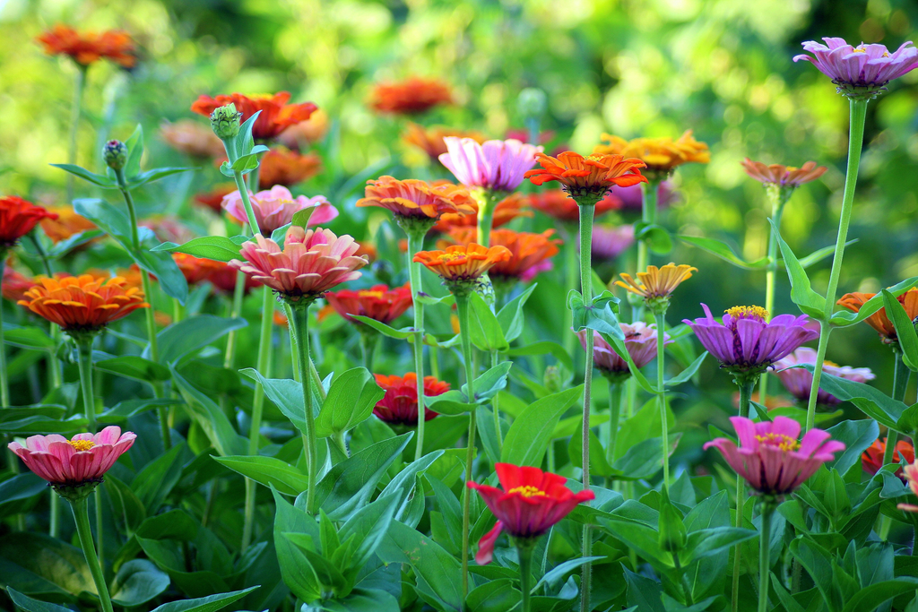

First flower

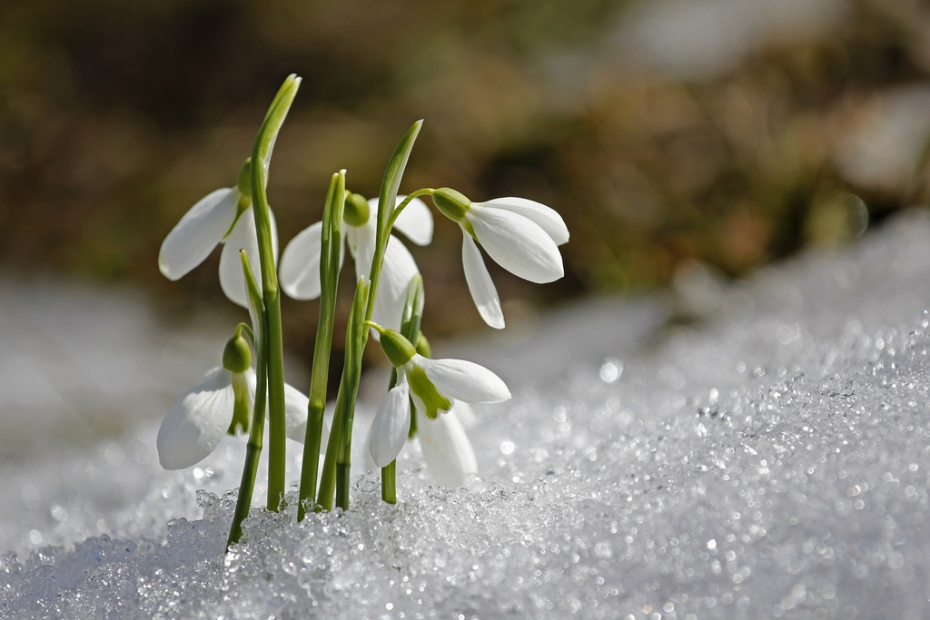

Second flower

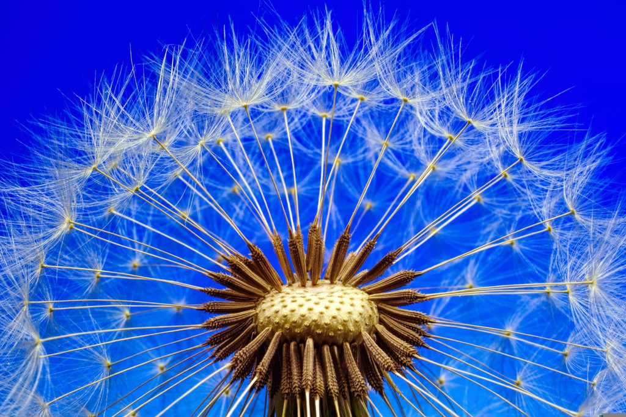

Third flower

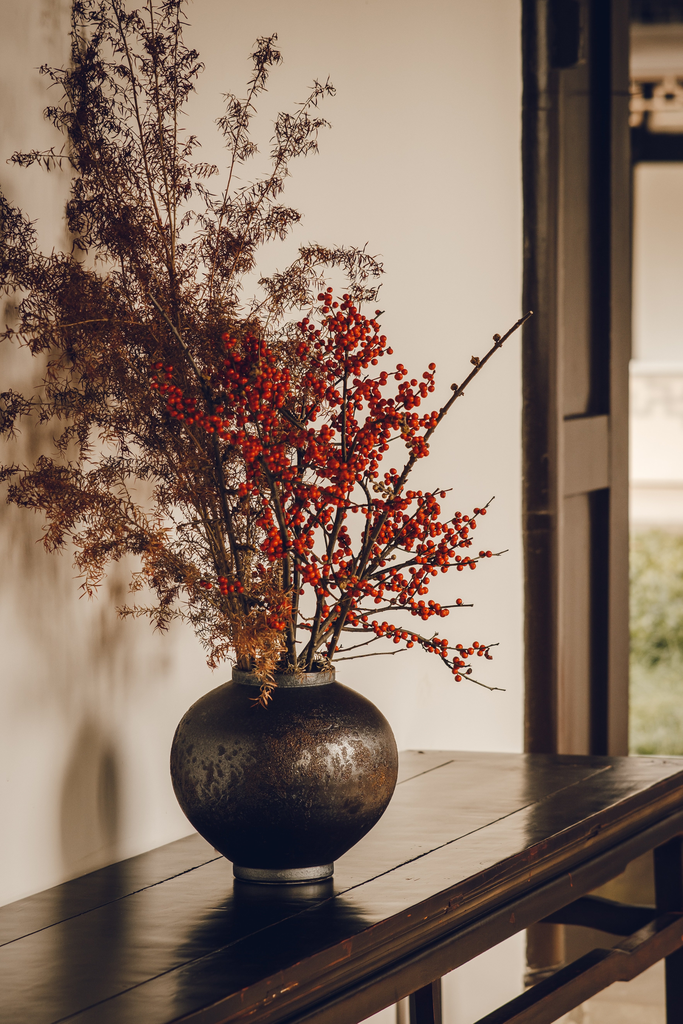

Fourth flower

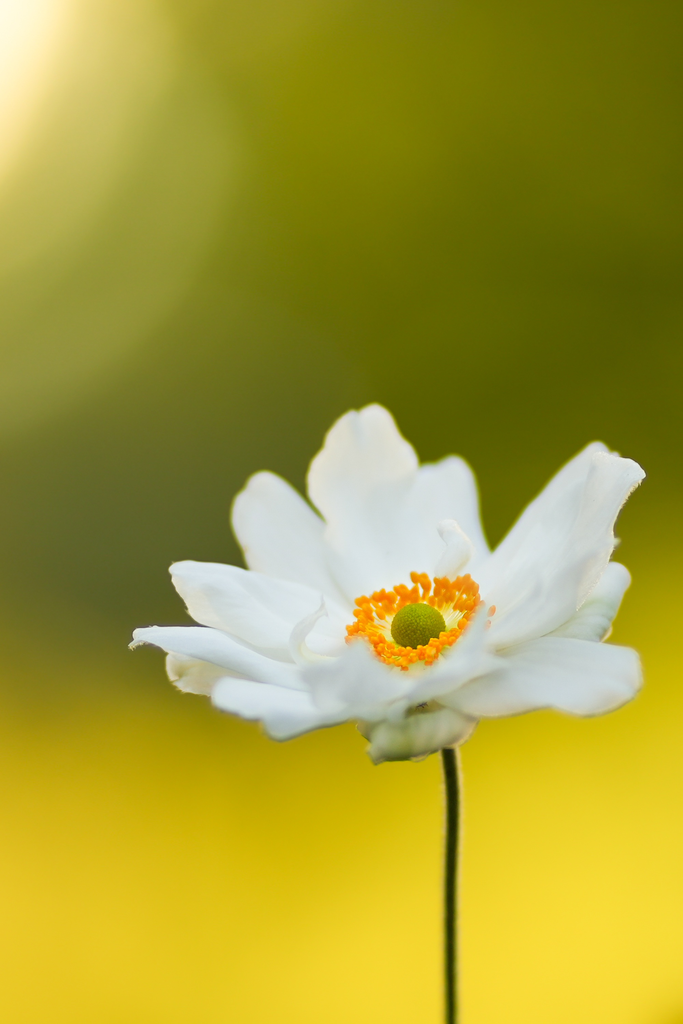

Fifth flower

### Item order

Items fill the grid in row-major order, left to right and then down, in both HTML and paged output. This matches Typst’s own `grid`, so the same document lays out the same way in every target.

Any other order is a rearrangement of the item array, which is plain Typst and needs no support from Calepin. A column-major helper is a dozen lines:

```
#let column-major(items, columns: 3) = {
  let base = calc.div-euclid(items.len(), columns)
  let extra = calc.rem-euclid(items.len(), columns)
  let size = c => base + if c < extra { 1 } else { 0 }
  let start = c => range(c).map(size).sum(default: 0)
  let out = ()
  for row in range(size(0)) {
    for c in range(columns) {
      if row < size(c) { out.push(items.at(start(c) + row)) }
    }
  }
  out
}

#calepin.elements.gallery(column-major(images, columns: 3), columns: 3)
```

The same trick covers reversing, interleaving, or grouping items: transform the array, then hand it to `gallery`.

## Columns

`calepin.elements.columns` is output-aware, so the same call produces a plain Pico `.grid` for HTML and a `grid(...)` for paged output. Columns are equal-width, and the `columns:` count applies to both outputs: paged output uses it directly, while HTML sets the `--calepin-grid-columns` CSS variable, which the theme applies above Pico’s `.grid` breakpoint (on narrow screens items still stack in a single column). Items beyond the count wrap onto new rows, so six items with `columns: 3` form a two-row grid. Note that `wrap:` is unrelated to row wrapping: by default, each item is wrapped in a `<div>` so plain Typst blocks stay together as one grid cell; use `wrap: false` when the items already render as standalone HTML elements such as cards.

```
#calepin.elements.columns(
  columns: 2,
  wrap: false,
  [
    #calepin.elements.card[
      #heading(level: 3)[Left]
      Use an equal-width two-column layout for related content.
    ]
  ],
  [
    #calepin.elements.card[
      #heading(level: 3)[Right]
      Paged output renders this via Typst `grid(...)`; HTML uses `<div class="grid">` by default.
    ]
  ],
)
```

#### Left

Use an equal-width two-column layout for related content.

#### Right

Paged output renders this via Typst `grid(...)`; HTML uses `<div class="grid">` by default.

You can also request more than two columns:

```
#calepin.elements.columns(
  columns: 4,
  wrap: true,
  [One], [Two], [Three]
)
```

One

Two

Three

## Tabs

`calepin.elements.tabs` renders Web Awesome tabs in HTML and lists each enabled panel in paged output. Use `calepin.elements.tabs[...]` as the container and `calepin.elements.tab("Label", active: true)[...]` for each panel. Panel names are generated automatically and uniquely; pass `name: "..."` only when you need a stable custom panel id. Fenced code chunks inside tabs are still discovered and executed. For offline or CSP-restricted HTML, pass `module-url` to the tabs container to use a locally hosted Web Awesome tab-group module. The module is emitted once, so every tabs container on a page must use the same URL; conflicting values produce a compile-time error.

Pass the same `group: "..."` value to multiple tab containers to keep their selection synchronized by panel name. As in Quarto tabset groups, selecting a panel in one container selects the corresponding panel in every other container in the group. Repeated labels are matched by their occurrence among enabled tabs, while their generated DOM panel ids remain unique. Containers without `group` remain independent.

````
#calepin.elements.tabs[
  #calepin.elements.tab("R", active: true)[
This tab shows R code:

```r
x <- c(1, 2, 3, 4, 5)
mean(x)
```
  ]

  #calepin.elements.tab("Python")[
This tab shows Python code:

```python
x = [1, 2, 3, 4, 5]
sum(x) / len(x)
```
  ]
]
````

R

This tab shows R code:

```
x <- c(1, 2, 3, 4, 5)
mean(x)
```

```
[1] 3
```

Python

This tab shows Python code:

```
x = [1, 2, 3, 4, 5]
sum(x) / len(x)
```

```
3.0
```

### Synchronized groups

Give multiple tab containers the same `group` name to keep their selected panels synchronized in HTML output. The first two containers below belong to the `language` group. Selecting R or Python in either one changes both.

RThe first container is showing its R content.PythonThe first container is showing its Python content.RThe second container follows the first container to R.PythonThe second container follows the first container to Python.

This container has no `group` argument, so its selection changes independently of the two containers above.

RThis independent container is showing its R content.PythonThis independent container is showing its Python content.

## Lightbox

`lightbox-image(...)` and `lightbox-video(...)` produce browser-only interactive media wrappers in HTML while degrading gracefully in paged output.

```
#calepin.elements.lightbox-image(
  "editor-image",
  "/assets/screenshot_notebook.png",
  "Notebook screenshot",
  width: 16em,
)
#calepin.elements.lightbox-video(
  "editor-video",
  "/assets/calepin_vscode.mp4",
  poster: "/assets/calepin_vscode-thumb.png",
  alt: "The Calepin extension running in VS Code",
  width: 16em,
)
```

For lower-level browser-only components, see Custom web elements.

On this page